# ZZSC5960 Bayesian Inference and Computation for Data Scientists

Bayesian analysis project: Vinho Verde

Mohammad Hosseinzadeh z5388543

Last updated: 15 August, 2021

### Introduction

We will be performing a logistic regression analysis on the wine dataset provided by Cortez, P et.al (2009) which was described in [Modeling wine preferences by data mining from physiochemical properties](https://www.sciencedirect.com/science/article/abs/pii/S0167923609001377?casa_token=3l0RostJJXAAAAAA:QC5SBNWeoP2No8AVCA8EMu4R9yLCBh5gyZvsEMEVT1DxrzPwybfUyU0fWb8u4sqeqSyIUQBuIQI). The dataset contains 12 variables, 11 input variables and one output variable as well as 1599 observations. The data is related to the different red variants of the Portuguese “Vinho Verde” wine.

The 11 input variables are based on physicochemical tests which include the following:

- *‘fixed acidity’* (numeric data)
- *‘volatile acidity’* (numeric data)
- *‘citric acid’* (numeric data)
- *‘residual sugar’* (numeric data)
- *‘chlorides’* (numeric data)
- *‘free sulfur dioxide’* (numeric data)
- *‘total sulfur dioxide’* (numeric data)
- *‘density’* (numeric data)
- *‘pH’* (numeric data)
- *‘sulphates’* (numeric data)
- *‘alcohol’* (numeric data).

The output variable is based on sensory data and is scored between 0 and 10:

- *‘quality’* (numeric data)

#### Logistic regression

Logistic regression is used to model *classification problems* where we attempt to predict the probability of a categorical response. Instead of predicting the value of the response variable, the logistic regression model will predict the probability that the value of response is *TRUE*.

### Read Data

```r
# read data
df <- read_csv("winequality-red.csv")
```

```r
# View head of df
head(df) %>%
  kbl(align = "l") %>%
  kable_classic("hover") %>%
  footnote(general_title = "Table 1: ",
           general = "The physicochemic data per wine type (first six rows)",
           footnote_as_chunk = TRUE)
```

| fixed acidity | volatile acidity | citric acid | residual sugar | chlorides | free sulfur dioxide | total sulfur dioxide | density | pH | sulphates | alcohol | quality |
| --- | --- | --- | --- | --- | --- | --- | --- | --- | --- | --- | --- |
| 7.4 | 0.70 | 0.00 | 1.9 | 0.076 | 11 | 34 | 0.9978 | 3.51 | 0.56 | 9.4 | 5 |
| 7.8 | 0.88 | 0.00 | 2.6 | 0.098 | 25 | 67 | 0.9968 | 3.20 | 0.68 | 9.8 | 5 |
| 7.8 | 0.76 | 0.04 | 2.3 | 0.092 | 15 | 54 | 0.9970 | 3.26 | 0.65 | 9.8 | 5 |
| 11.2 | 0.28 | 0.56 | 1.9 | 0.075 | 17 | 60 | 0.9980 | 3.16 | 0.58 | 9.8 | 6 |
| 7.4 | 0.70 | 0.00 | 1.9 | 0.076 | 11 | 34 | 0.9978 | 3.51 | 0.56 | 9.4 | 5 |
| 7.4 | 0.66 | 0.00 | 1.8 | 0.075 | 13 | 40 | 0.9978 | 3.51 | 0.56 | 9.4 | 5 |

Table 1: The physicochemic data per wine type (first six rows)

#### Inspect data

Inspect and check data for missing values. If any NA were found, remove them from the data frame.

```r
# check total number of NA values in df
sum(is.na(df))
```

```
## [1] 0
```

There were no missing values found in the dataset. Therefore, there was no need to remove any data.

### Response variable

For the implementation of our logistic regression, we want a response variable will assume values of either 0 or 1 variables. We will consider a wine to be of “good” quality with a score above 6.5 (inclusive).

```r
# add response variable - for quality >= 6.5 assign 1 (good);
# for quality < 6.5 assign 0 (poor)
df <- df %>%
  mutate(response = if_else(quality >= 6.5, 1, 0))

# display total number of 0 and 1 response values
df %>%
  group_by(response) %>%
  summarise(n = n())
```

```
## # A tibble: 2 x 2
##   response     n
##      <dbl> <int>
## 1        0  1382
## 2        1   217
```

### Logisitic regression model

The response variable from our dataset has two possible values: *poor* and *good*, which is represented by 0 and 1. Therefore, the type of logistic regression to model such a dataset is a binomial logistic regression.

We will use the glm() function from the *stats* package to build a logistic regression model.

```r
set.seed(1234)
# build binomial logistic regression model
lr_model <- glm(
  formula = response ~ `fixed acidity` +
    `volatile acidity` + `citric acid` +
    `residual sugar` + chlorides +
    `free sulfur dioxide` + `total sulfur dioxide` +
    density + pH + sulphates + alcohol,
  family = binomial(link = "logit"),
  x = TRUE,
  data = df)
```

### Evaluate model - frequentist analysis

The *base R* summary() function can be used to display a detailed description of our trained model. This includes the estimated coefficients for each regressor, the standard error, z-value, p-value, and the significance of each regressor.

```r
set.seed(1234)
# display results of the model
lr_model %>% summary()
```

```
##
## Call:
## glm(formula = response ~ `fixed acidity` + `volatile acidity` +
##     `citric acid` + `residual sugar` + chlorides + `free sulfur dioxide` +
##     `total sulfur dioxide` + density + pH + sulphates + alcohol,
##     family = binomial(link = "logit"), data = df, x = TRUE)
##
## Deviance Residuals:
##     Min       1Q   Median       3Q      Max
## -2.9878  -0.4351  -0.2207  -0.1222   2.9869
##
## Coefficients:
##                          Estimate Std. Error z value Pr(>|z|)
## (Intercept)             2.428e+02  1.081e+02   2.247 0.024660 *
## `fixed acidity`         2.750e-01  1.253e-01   2.195 0.028183 *
## `volatile acidity`     -2.581e+00  7.843e-01  -3.291 0.000999 ***
## `citric acid`           5.678e-01  8.385e-01   0.677 0.498313
## `residual sugar`        2.395e-01  7.373e-02   3.248 0.001163 **
## chlorides              -8.816e+00  3.365e+00  -2.620 0.008788 **
## `free sulfur dioxide`   1.082e-02  1.223e-02   0.884 0.376469
## `total sulfur dioxide` -1.653e-02  4.894e-03  -3.378 0.000731 ***
## density                -2.578e+02  1.104e+02  -2.335 0.019536 *
## pH                      2.242e-01  9.984e-01   0.225 0.822327
## sulphates               3.750e+00  5.416e-01   6.924 4.39e-12 ***
## alcohol                 7.533e-01  1.316e-01   5.724 1.04e-08 ***
## ---
## Signif. codes:  0 '***' 0.001 '**' 0.01 '*' 0.05 '.' 0.1 ' ' 1
##
## (Dispersion parameter for binomial family taken to be 1)
##
##     Null deviance: 1269.92  on 1598  degrees of freedom
## Residual deviance:  870.86  on 1587  degrees of freedom
## AIC: 894.86
##
## Number of Fisher Scoring iterations: 6
```

The following coefficients are not significant in predicting the response variable based on their p-values:

- *citric acid*: **not significant**, $p >0.05$
- *free sulfur dioxide*: **not significant**, $p >0.05$
- *pH*: **not significant**, $p >0.05$

### Probability estimation - “success”

For this task, we will fix each covariate at its mean level, and compute the probabilities for a wine to score “good” (>= 6.5) varying *‘total sulfur dioxide’*.

In generalised linear models (GLMs), the model is defined on a transformation $g(.)$ of the mean value $\mu_i$:

$$\eta_i = g[E(Y_i)] = g(\mu_i)$$
and the model of $g(\mu_i)$ is linear:

$$g(\mu_i) = x_i{\beta}$$

For a binomial logistic regression, the link function $g(.)$ as defined by the canonical link is:

$$\eta_i = log(\frac{\pi_i}{1 - \pi_i}) = x_i{\beta}$$
where:

- $\eta_i$ is the **linear predictor**
- $g(.)$ is the **link function**
- $\beta$ is a column vector of parameters of dimension $(k+1)1$
- $x_i$ is the i-th row of the design matrix $X$ with dimensions $1(k+1)$.

To then convert the computed log-odds into probability, we will use the inverse logit function:

$$p = \frac{1}{1 + e^{-x}} = \frac{exp(x_i{\beta})}{1 + exp(x_i{\beta})}$$

where:

- $p$ is the probability
- $e$ is Euler’s number.

To compute the log-odds of success for varying *‘total sulfur dioxide’*, we will use the following formula:

$$log odds = \beta_0 + \beta{_1}x_1 + \beta{_2}x_2,...\beta{_k}x_k$$

with the default threshold probability is 0.5. Therefore, if the probability is $>0.5$, it will be classified as “good” quality wine. If the probability is $<0.5$, it will be classified as “bad” quality wine.

```r
set.seed(1234)
### assign log odds of each coefficient from the logistic regression model

# b0 - intercept
b0 <- lr_model$coefficients[1]

# b1 - `fixed acidity`
b1 <- lr_model$coefficients[2]

# b2 - `volatile acidity`
b2 <- lr_model$coefficients[3]

# b3 - `citric acid`
b3 <- lr_model$coefficients[4]

# b4 - `residual sugar`
b4 <- lr_model$coefficients[5]

# b5 - chlorides
b5 <- lr_model$coefficients[6]

# b6 - `free sulfur dioxide`
b6 <- lr_model$coefficients[7]

# b7 - `total sulfur dioxide`
b7 <- lr_model$coefficients[8]

# b8 - density
b8 <- lr_model$coefficients[9]

# b9 - pH
b9 <- lr_model$coefficients[10]

# b10 - sulphates
b10 <- lr_model$coefficients[11]

# b11 - alcohol
b11 <- lr_model$coefficients[12]

### compute mean for each coefficient

# b1 - `fixed acidity`
b1_mean <- mean(df$`fixed acidity`)

# b2 - `volatile acidity`
b2_mean <- mean(df$`volatile acidity`)

# b3 - `citric acid`
b3_mean <- mean(df$`citric acid`)

# b4 - `residual sugar`
b4_mean <- mean(df$`residual sugar`)

# b5 - chlorides
b5_mean <- mean(df$chlorides)

# b6 - `free sulfur dioxide`
b6_mean <- mean(df$`free sulfur dioxide`)

# b7 - `total sulfur dioxide`
b7_mean <- mean(df$`total sulfur dioxide`)

# b8 - density
b8_mean <- mean(df$density)

# b9 - pH
b9_mean <- mean(df$pH)

# b10 - sulphates
b10_mean <- mean(df$sulphates)

# b11 - alcohol
b11_mean <- mean(df$alcohol)
```

```r
set.seed(1234)
# sequential vector of range for b7 - `total sulfur dioxide`
b7_range <- seq(from = min(df$`total sulfur dioxide`),
                to = max(df$`total sulfur dioxide`),
                by = 1)

# compute "success" logit for varying total sulfur dioxide - b7
b7_logit_good <- b0 +
  b1 * b1_mean +
  b2 * b2_mean +
  b3 * b3_mean +
  b4 * b4_mean +
  b5 * b5_mean +
  b6 * b6_mean +
  b7 * b7_range +
  b8 * b8_mean +
  b9 * b9_mean +
  b10 * b10_mean +
  b11 * b11_mean

# compute "success" probability for varying total sulfur dioxide - b7
b7_prob_good <- exp(b7_logit_good) / (1 + exp(b7_logit_good))

# create df for use with ggplot2 for plotting graph
tsd_df <- data.frame(b7_range = b7_range,
                     b7_logit_good = b7_logit_good,
                     b7_prob_good = b7_prob_good)
```

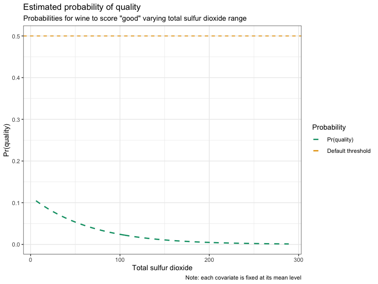

```r
# Plot estimated Pr(success) varying total sulfur dioxide range

# colour palette - colour-blind friendly
orange <- "#E69F00"
skyblue <- "#56B4E9"
bluish_green <- "#009E73"
yellow <- "#F0E442"
vermilion <- "#D55E00"
redish_purple <- "#CC79A7"

# plot title
p1_title <- 'Estimated probability of quality'

# subtitle
p1_subtitle <- 'Probabilities for wine to score "good" varying total sulfur dioxide range'

# plot the estimated probabilities of "good" wine score for varying sulf diox
tsd_df %>%
  ggplot(aes(x = b7_range, y = b7_prob_good)) +
  geom_line(aes(colour = "bluish_green"), linetype = 2, size = 0.9) +
  geom_hline(colour = orange, yintercept = 0.5, linetype = 2, size = 0.6) +
  xlab("Total sulfur dioxide") +
  ylab("Pr(quality)") +
  labs(subtitle = p1_subtitle,
       caption = "Note: each covariate is fixed at its mean level") +
  ggtitle(p1_title) +
  scale_colour_manual(name="Probability",
                      values = c("bluish_green" = bluish_green,
                                 orange = orange),
                      labels = c("Pr(quality)", "Default threshold")) +
  theme_bw()
```

### Task 6: Bayesian analysis of the logistic model

For this task, we are required to approximate the posterior distributions of the regression coefficients by the following steps:

1. Write an $R$ function for the log posterior distribution.
2. Fix the number of simulation at $10^4$.
3. Choose 4 different initialisations for the coefficients.
4. For each initialisation, run a Metropolis–Hastings algorithm.
5. Plot the chains for each coefficients (the 4 chains on the same plot) and comment.
6. Approximate the posterior predictive distribution of an unobserved variable characterised by the following:
- *fixed acidity*: 7.5
- *volatile acidity*: 0.6
- *citric acid*: 0.0
- *residual sugar*: 1.70
- *chlorides*: 0.085
- *free sulfur dioxide*: 5
- *total sulfur dioxide*: 45
- *density*: 0.9965
- *pH*: 3.40
- *sulphates*: 0.63
- *alcohol*: 12

We will assume an independent normal prior distribution of $N(0, 10)$ with mean 0 and standard deviation 10.

Note:

- *‘logp’* is a contribution to the log-likelihood only in the case of $y=1$.
- *‘logq’* is a contribution to the log-likelihood only in the case of $y=0$.
- A symmetric normal distribution was chosen as the proposal distribution, which allows the acceptance probability of the Metropolis-Hastings algorithm to be simplified to the ratio of the posterior densities.

```r
set.seed(1234)
# function for the log posterior distribution
log_posterior <- function(beta, x, y) {
    # compute eta
    eta <- as.numeric(x %*% beta)

    # compute probability y = 1 in log-scale of logistic function
    logp <- ifelse(eta < 0, eta - log1p(exp(eta)), - log1p(exp(- eta)))

    # compute probability y = 0 in log-scale of logistic function
    logq <- ifelse(eta < 0, - log1p(exp(eta)), - eta - log1p(exp(- eta)))

    # compute log-scale likelihood distribution
    logl <- sum(logp[y == 1]) + sum(logq[y == 0])

    # compute log-scale prior distribution
    lprior <- sum(dnorm(beta, 0, 10, log = TRUE))
    # compute log-scale posterior distribution
    return(logl + lprior)
}

### Metropolis-Hastings algorithm for the logistic regression model - setup
# set number of simulations
sims <- 10^4

# design matrix
X <- cbind(
  rep(1, nrow(df)), #column of value 1 which is to be multiplied intercept
  df$`fixed acidity`,
  df$`volatile acidity`,
  df$`citric acid`,
  df$`residual sugar`,
  df$chlorides,
  df$`free sulfur dioxide`,
  df$`total sulfur dioxide`,
  df$density,
  df$pH,
  df$sulphates,
  df$alcohol
)

# response variable
y <- df$response

# omega matrix for use as SD when simulating rmvnorm values
omega_prop <- solve(t(X) %*% X)

### Beta matrix 1
# create empty matrix to save all simulated beta values
beta_matrix <- matrix(NA, nrow = sims, ncol = ncol(X))

# numeric vecotr of coefficeint estimates from logistic regression model - MLE
beta_init <- as.numeric(coefficients(lr_model))

# initialise the beta matrix by using the MLE of the logistic regression model
beta_matrix[1, ] <- beta_init

### Beta matrix 2
# create empty matrix to save all simulated beta values
beta_matrix2 <- matrix(NA, nrow = sims, ncol = ncol(X))

# initialise beta matrix2 with all values set at 0
beta_matrix2[1, ] <- rep(0, 12)

### Beta matrix 3
# create empty matrix to save all simulated beta values
beta_matrix3 <- matrix(NA, nrow = sims, ncol = ncol(X))

# initialise beta matrix3 with high value for intercept and 0 for the others
beta_matrix3[1, ] <- c(200, 0, 0, 0, 0, 0, 0, 0, -200, 0, 0, 0)

### Beta matrix 4
# create empty matrix to save all simulated beta values
beta_matrix4 <- matrix(NA, nrow = sims, ncol = ncol(X))

# initialise beta matrix4 with random values
beta_matrix4[1, ] <- rmvnorm(1, mean = beta_init, sigma = 2*omega_prop)
```

Since the absolute value of the coefficients is quite variable, we can use different tuning standard deviations for each parameter. One way to do that is to simulate all the coefficients together and linking the variance-covariance matrix to the coefficients. This method allows for the absolute value of the coefficients to be linked to the variance associated to the MLE:

$$\beta^* \sim N(\beta^{iter-1}, c \times (X^TX)^{-1})$$
where $c$ is a tuning parameter. Different values for $c$ were experimented with to find the most suitable value so that the chosen standard deviation can result in the final acceptance rate being as close to the optimal rate of 0.234 (Roberts & Rosenthal 2001). Given our dataset, $c=0.8$ was found to obtain the desired acceptance rate.

To compute $(X^TX)^{-1}$, we can use the following base R functions:

- *solve()* to compute the inverse **% * %** for the matrix product
- *t()* to compute the transpose.

```r
# Run Metropolis-Hastings algorithm for Beta_Matrix 1 - MLE initialisation
set.seed(1234)

# number of values accepted
accepted <- 0

# vectors for prediction;
# Note: the initial value of 1 in the vectors is the value used to be multiplied by the intercept
x_new <- c(1, 7.5, 0.6, 0.0, 1.70, 0.085, 5, 45, 0.9965, 3.40, 0.63, 12)
y_new <- c(1)

# M-H algorithm for simulations minus 1 iterations (we have already made the initialisation)
for(iter in 2:sims) {

  # 1. propose a new set of values - simulate all beta star values together
  # with normal proposal distribution; mean = the values of beta simulated
  # at the previous iteration, SD = 0.5 * omega_prop
  beta_star <- rmvnorm(n = 1,
                       mean = beta_matrix[iter-1, ],
                       sigma = 0.8 * omega_prop)

  # 2. compute the posterior density on the proposed value and on the old value
  new_posterior <- log_posterior(t(beta_star), X, y)
  old_posterior <- log_posterior(matrix(beta_matrix[iter-1, ], ncol=1), X, y)

  # 3. acceptance step
  if(runif(1, 0, 1) > exp(new_posterior - old_posterior)) {
    beta_matrix[iter, ] <- beta_matrix[iter-1, ]
  } else {
    beta_matrix[iter, ] <- beta_star
    accepted <- accepted + 1
  }

  # 4. print the stage of the chain
  if(iter %% 1000 == 0) {
    print(c(iter, accepted/iter))
  }

  # 5. prediction

  # compute the probability of a new observation;
  # normalised by computing the logistic function
  p_new <- exp(sum(beta_matrix[iter, ] * x_new)) /
    (1 + exp(sum(beta_matrix[iter, ] * x_new)))

  # simulate new y values from a Bernoulli distribution
  y_new[iter] <- rbinom(1, 1, prob = p_new)
}
```

```
## [1] 1000.000    0.252
## [1] 2000.000    0.239
## [1] 3000.0000000    0.2303333
## [1] 4000.0000    0.2255
## [1] 5000.000    0.228
## [1] 6000.0000000    0.2266667
## [1] 7000.0000000    0.2255714
## [1] 8000.0000    0.2255
## [1] 9000.0000000    0.2253333
## [1] 1.000e+04 2.248e-01
```

```r
# Run Metropolis-Hastings algorithm for Beta_Matrix 2
set.seed(1234)

# number of values accepted
accepted2 <- 0

# vectors for prediction
x_new2 <- c(1, 7.5, 0.6, 0.0, 1.70, 0.085, 5, 45, 0.9965, 3.40, 0.63, 12)
y_new2 <- c(1)

# Metropolis-Hastings algorithm for sims minus 1 iterations
for(iter2 in 2:sims) {

  # 1. propose a new set of values - simulate all beta star values together
  # with normal proposal distribution; mean = the values of beta simulated
  # at the previous iteration, SD =
  beta_star2 <- rmvnorm(n = 1,
                       mean = beta_matrix2[iter2-1, ],
                       sigma = 0.8 * omega_prop)

  # 2. compute the posterior density on the proposed value and on the old value
  new_posterior2 <- log_posterior(t(beta_star2), X, y)
  old_posterior2 <- log_posterior(matrix(beta_matrix2[iter2-1, ], ncol=1), X, y)

  # 3. acceptance step
  if(runif(1, 0, 1) > exp(new_posterior2 - old_posterior2)) {
    beta_matrix2[iter2, ] <- beta_matrix2[iter2-1, ]
  } else {
    beta_matrix2[iter2, ] <- beta_star2
    accepted2 <- accepted2 + 1
  }

  # 4. print the stage of the chain
  if(iter2 %% 1000 == 0) {
    print(c(iter2, accepted2/iter2))
  }

  # 5. prediction

  # compute the probability of a new observation;
  # normalised by computing the logistic function
  p_new2 <- exp(sum(beta_matrix2[iter2, ] * x_new2)) /
    (1 + exp(sum(beta_matrix2[iter2, ] * x_new2)))

  # simulate new y values from a Bernoulli distribution
  y_new2[iter2] <- rbinom(1, 1, prob = p_new2)
}
```

```
## [1] 1000.000    0.269
## [1] 2000.0000    0.2385
## [1] 3000.000    0.236
## [1] 4000.00000    0.22675
## [1] 5000.000    0.226
## [1] 6000.0000000    0.2268333
## [1] 7000.0000000    0.2265714
## [1] 8000.000000    0.225375
## [1] 9000.0000000    0.2253333
## [1] 1.000e+04 2.238e-01
```

```r
# Run Metropolis-Hastings algorithm Beta_Matrix 3
set.seed(1234)

# number of values accepted
accepted3 <- 0

# vectors for prediction
x_new3 <- c(1, 7.5, 0.6, 0.0, 1.70, 0.085, 5, 45, 0.9965, 3.40, 0.63, 12)
y_new3 <- c(1)

# Metropolis-Hastings algorithm for sims minus 1 iterations
for(iter3 in 2:sims) {

  # 1. propose a new set of values - simulate all beta star values together
  # with normal proposal distribution; mean = the values of beta simulated
  # at the previous iteration, SD =
  beta_star3 <- rmvnorm(n = 1,
                       mean = beta_matrix3[iter3-1, ],
                       sigma = 0.8 * omega_prop)

  # 2. compute the posterior density on the proposed value and on the old value
  new_posterior3 <- log_posterior(t(beta_star3), X, y)
  old_posterior3 <- log_posterior(matrix(beta_matrix3[iter3-1, ], ncol=1), X, y)

  # 3. acceptance step
  if(runif(1, 0, 1) > exp(new_posterior3 - old_posterior3)) {
    beta_matrix3[iter3, ] <- beta_matrix3[iter3-1, ]
  } else {
    beta_matrix3[iter3, ] <- beta_star3
    accepted3 <- accepted3 + 1
  }

  # 4. print the stage of the chain
  if(iter3 %% 1000 == 0) {
    print(c(iter3, accepted3/iter3))
  }

  # 5. prediction

  # compute the probability of a new observation;
  # normalised by computing the logistic function
  p_new3 <- exp(sum(beta_matrix3[iter3, ] * x_new3)) /
    (1 + exp(sum(beta_matrix3[iter3, ] * x_new3)))

  # simulate new y values from a Bernoulli distribution
  y_new3[iter3] <- rbinom(1, 1, prob = p_new3)
}
```

```
## [1] 1000.000    0.282
## [1] 2000.0000    0.2515
## [1] 3000.0000000    0.2396667
## [1] 4000.00000    0.22425
## [1] 5000.000    0.227
## [1] 6000.0000000    0.2301667
## [1] 7000.0000000    0.2302857
## [1] 8000.000000    0.229125
## [1] 9000.0000000    0.2282222
## [1] 1.000e+04 2.265e-01
```

```r
# Metropolis-Hastings algorithm for Beta_Matrix 4
set.seed(1234)

# number of values accepted
accepted4 <- 0

# vectors for prediction
x_new4 <- c(1, 7.5, 0.6, 0.0, 1.70, 0.085, 5, 45, 0.9965, 3.40, 0.63, 12)
y_new4 <- c(1)

# Metropolis-Hastings algorithm for sims minus 1 iterations (we have already made the initialisation)
for(iter4 in 2:sims) {

  # 1. propose a new set of values - simulate all beta star values together
  # with normal proposal distribution; mean = the values of beta simulated
  # at the previous iteration, SD =
  beta_star4 <- rmvnorm(n = 1,
                       mean = beta_matrix4[iter4-1, ],
                       sigma = 0.8 * omega_prop)

  # 2. compute the posterior density on the proposed value and on the old value
  new_posterior4 <- log_posterior(t(beta_star4), X, y)
  old_posterior4 <- log_posterior(matrix(beta_matrix4[iter4-1, ], ncol=1), X, y)

  # 3. acceptance step
  if(runif(1, 0, 1) > exp(new_posterior4 - old_posterior4)) {
    beta_matrix4[iter4, ] <- beta_matrix4[iter4-1, ]
  } else {
    beta_matrix4[iter4, ] <- beta_star4
    accepted4 <- accepted4 + 1
  }

  # 4. print the stage of the chain
  if(iter4 %% 1000 == 0) {
    print(c(iter4, accepted4/iter4))
  }

  # 5. prediction

  # compute the probability of a new observation;
  # normalised by computing the logistic function
  p_new4 <- exp(sum(beta_matrix4[iter4, ] * x_new4)) /
    (1 + exp(sum(beta_matrix4[iter4, ] * x_new4)))

  # simulate new y values from a Bernoulli distribution
  y_new4[iter4] <- rbinom(1, 1, prob = p_new4)
}
```

```
## [1] 1000.000    0.265
## [1] 2000.0000    0.2405
## [1] 3000.000    0.232
## [1] 4000.000    0.221
## [1] 5000.0000    0.2234
## [1] 6000.000    0.224
## [1] 7000.0000000    0.2258571
## [1] 8000.00000    0.22725
## [1] 9000.0000000    0.2278889
## [1] 1.000e+04 2.268e-01
```

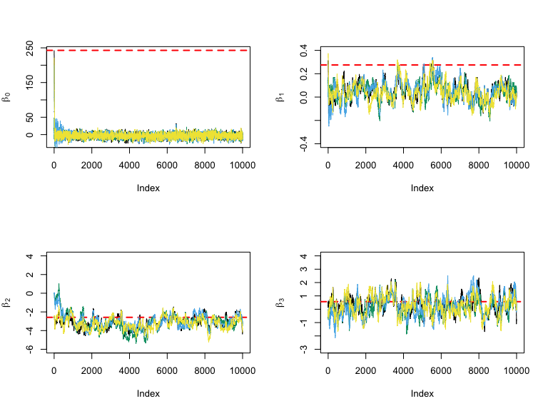

```r
# Plot of all initialisations Markov chains - B0-B3
set.seed(1234)
par(mfrow = c(2, 2))

# coefficient B0
plot(beta_matrix[, 1], type = "l", ylab = expression(beta[0]))
abline(h = lr_model$coefficients[1], col = "red", lty = 2, lwd = 2)
lines(beta_matrix2[, 1], col = bluish_green)
lines(beta_matrix3[, 1], col = skyblue)
lines(beta_matrix4[, 1], col = yellow)

# coefficient B1
plot(beta_matrix[, 2], type = "l", ylab = expression(beta[1]),
     ylim = c(-0.4, 0.4))
abline(h = lr_model$coefficients[2], col = "red", lty = 2, lwd = 2)
lines(beta_matrix2[, 2], col = bluish_green)
lines(beta_matrix3[, 2], col = skyblue)
lines(beta_matrix4[, 2], col = yellow)

# coefficient B2
plot(beta_matrix[, 3], type = "l", ylab = expression(beta[2]),
     ylim = c(-6, 4))
abline(h = lr_model$coefficients[3], col = "red", lty = 2, lwd = 2)
lines(beta_matrix2[, 3], col = bluish_green)
lines(beta_matrix3[, 3], col = skyblue)
lines(beta_matrix4[, 3], col = yellow)

# coefficient B3
plot(beta_matrix[, 4], type = "l", ylab = expression(beta[3]),
     ylim = c(-3, 4))
abline(h = lr_model$coefficients[4], col = "red", lty = 2, lwd = 2)
lines(beta_matrix2[, 4], col = bluish_green)
lines(beta_matrix3[, 4], col = skyblue)
lines(beta_matrix4[, 4], col = yellow)
```

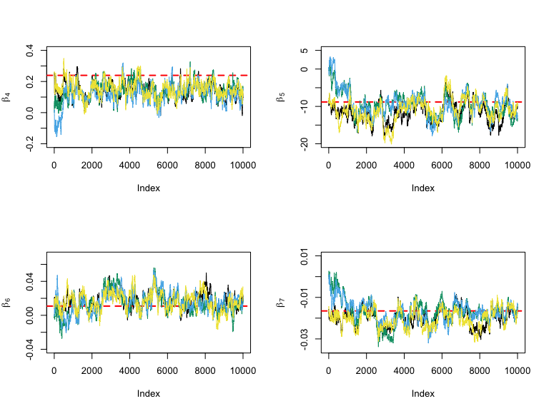

```r
# Plot of all initialisations Markov chains - B4-B7
set.seed(1234)
par(mfrow = c(2, 2))

# coefficient B4
plot(beta_matrix[, 5], type = "l", ylab = expression(beta[4]),
     ylim = c(-0.2, 0.4))
abline(h = lr_model$coefficients[5], col = "red", lty = 2, lwd = 2)
lines(beta_matrix2[, 5], col = bluish_green)
lines(beta_matrix3[, 5], col = skyblue)
lines(beta_matrix4[, 5], col = yellow)

# coefficient B5
plot(beta_matrix[, 6], type = "l", ylab = expression(beta[5]),
     ylim = c(-20, 5))
abline(h = lr_model$coefficients[6], col = "red", lty = 2, lwd = 2)
lines(beta_matrix2[, 6], col = bluish_green)
lines(beta_matrix3[, 6], col = skyblue)
lines(beta_matrix4[, 6], col = yellow)

# coefficient B6
plot(beta_matrix[, 7], type = "l", ylab = expression(beta[6]),
     ylim = c(-0.04, 0.07))
abline(h = lr_model$coefficients[7], col = "red", lty = 2, lwd = 2)
lines(beta_matrix2[, 7], col = bluish_green)
lines(beta_matrix3[, 7], col = skyblue)
lines(beta_matrix4[, 7], col = yellow)

# coefficient B7
plot(beta_matrix[, 8], type = "l", ylab = expression(beta[7]),
     ylim = c(-0.035, 0.01))
abline(h = lr_model$coefficients[8], col = "red", lty = 2, lwd = 2)
lines(beta_matrix2[, 8], col = bluish_green)
lines(beta_matrix3[, 8], col = skyblue)
lines(beta_matrix4[, 8], col = yellow)
```

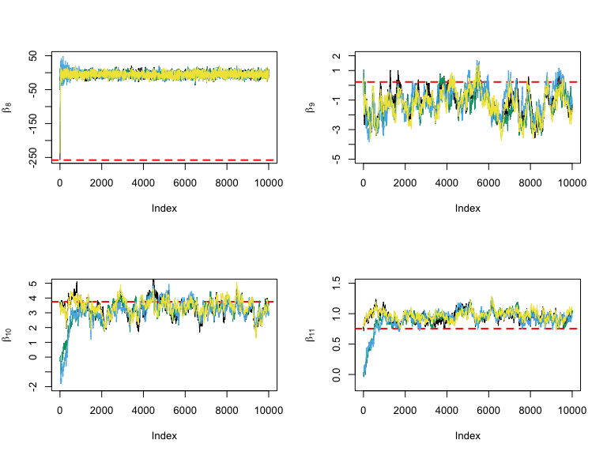

```r
# Plot of all initialisations Markov chains - B8-B12
set.seed(1234)
par(mfrow = c(2, 2))

# coefficient B8
plot(beta_matrix[, 9], type = "l", ylab = expression(beta[8]),
     ylim = c(-255, 50))
abline(h = lr_model$coefficients[9], col = "red", lty = 2, lwd = 2)
lines(beta_matrix2[, 9], col = bluish_green)
lines(beta_matrix3[, 9], col = skyblue)
lines(beta_matrix4[, 9], col = yellow)

# coefficient B9
plot(beta_matrix[, 10], type = "l", ylab = expression(beta[9]),
     ylim = c(-5, 2))
abline(h = lr_model$coefficients[10], col = "red", lty = 2, lwd = 2)
lines(beta_matrix2[, 10], col = bluish_green)
lines(beta_matrix3[, 10], col = skyblue)
lines(beta_matrix4[, 10], col = yellow)

# coefficient B10
plot(beta_matrix[, 11], type = "l", ylab = expression(beta[10]),
     ylim = c(-2, 5))
abline(h = lr_model$coefficients[11], col = "red", lty = 2, lwd = 2)
lines(beta_matrix2[, 11], col = bluish_green)
lines(beta_matrix3[, 11], col = skyblue)
lines(beta_matrix4[, 11], col = yellow)

# coefficient B11
plot(beta_matrix[, 12], type = "l", ylab = expression(beta[11]),
     ylim = c(-0.2, 1.5))
abline(h = lr_model$coefficients[12], col = "red", lty = 2, lwd = 2)
lines(beta_matrix2[, 12], col = bluish_green)
lines(beta_matrix3[, 12], col = skyblue)
lines(beta_matrix4[, 12], col = yellow)
```

```r
# display the acceptance rate for each init 1
accepted / iter
```

```
## [1] 0.2248
```

```r
# display the acceptance rate for each init 2
accepted2 / iter2
```

```
## [1] 0.2238
```

```r
# display the acceptance rate for each init 3
accepted3 / iter3
```

```
## [1] 0.2265
```

```r
# display the acceptance rate for each init 4
accepted4 / iter4
```

```
## [1] 0.2268
```

Markov Chain Monte Carlo (MCMC) methods such as the Metropolis-Hastings involve simulating from complex target distribution, indirectly, and generating a Markov chain with the target distribution as its stationary distribution (Brooks & Gelman 1998). The simulated values are then considered as independent and identically distributed values from the target distribution once it reaches convergence. If the chain is run for a long time, the marginal distribution convergence to the stationary distribution regardless of the chains initial conditions (Blitzstein & Hwang 2015).

When assessing convergence for the chains produced for our dataset, we can see that the tuning parameters effecting the standard deviation of the proposal distribution, the choice of prior distribution as well as the choice of initialisation values effect convergence. Therefore, it is important to experiment with different choices and assess for convergence.

From our logistic regression model, we can see that we will require more simulations to run more chains for the coefficients to reach convergence. However, the *‘intercept’*, $\beta_0$, and *‘density’*, $\beta_8$ will not be suitable for estimation. When reviewing the variable *‘density’*, we can see that all its values are very similar. Therefore, when multiplied by the relative coefficient, the value does not vary by much with respect to the other covariates.

### Task 7: Plot the approximate posterior predictive distribution

The *‘y_new’* values predicted in the algorithm from task 6 will be used to plot the densities for each of the different coefficient initialisations the Metropolis-Hastings algorithm implementation.

```r
# dataframe of y predicted values for each different coef initialisation
predicted_df <- data.frame(y_pred1 = y_new[2000:10000],
                           y_pred2 = y_new2[2000:10000],
                           y_pred3 = y_new3[2000:10000],
                           y_pred4 = y_new4[2000:10000])

# summary of y predicted values for init 1
predicted_df %>%
  summarise(good_quality1 = sum(y_pred1 == 1),
            bad_quality1 = sum(y_pred1 == 0),
            n = good_quality1 + bad_quality1,
            ratio = round(good_quality1/bad_quality1, 4))
```

```
##   good_quality1 bad_quality1    n  ratio
## 1           824         7177 8001 0.1148
```

```r
# summary of y predicted values for init 2
predicted_df %>%
  summarise(good_quality2 = sum(y_pred2 == 1),
            bad_quality2 = sum(y_pred2 == 0),
            n = good_quality2 + bad_quality2,
            ratio = round(good_quality2/bad_quality2, 4))
```

```
##   good_quality2 bad_quality2    n  ratio
## 1           854         7147 8001 0.1195
```

```r
# summary of y predicted values for init 3
predicted_df %>%
  summarise(good_quality3 = sum(y_pred3 == 1),
            bad_quality3 = sum(y_pred3 == 0),
            n = good_quality3 + bad_quality3,
            ratio = round(good_quality3/bad_quality3, 4))
```

```
##   good_quality3 bad_quality3    n  ratio
## 1           853         7148 8001 0.1193
```

```r
# summary of y predicted values for init 4
predicted_df %>%
  summarise(good_quality4 = sum(y_pred4 == 1),
            bad_quality4 = sum(y_pred4 == 0),
            n = good_quality4 + bad_quality4,
            ratio = round(good_quality4/bad_quality4, 4))
```

```
##   good_quality4 bad_quality4    n ratio
## 1           825         7176 8001 0.115
```

```r
# ratio of good to bad quality wine in the dataset
df %>%
  summarise(ratio = sum(response==1) / sum(response == 0))
```

```
## # A tibble: 1 x 1
##   ratio
##   <dbl>
## 1 0.157
```

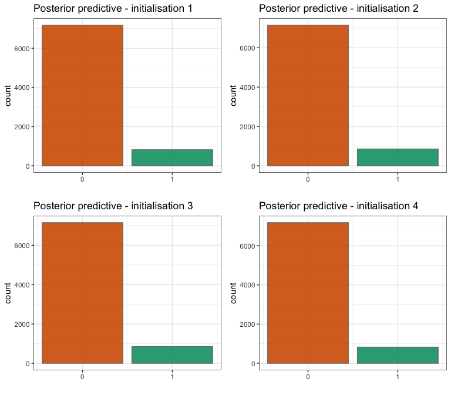

```r
# bar plot - init 1
bp1 <- predicted_df %>%
  ggplot(aes(y_pred1)) +
  geom_bar(fill = c(vermilion, bluish_green),
           colour = "grey50", alpha = 0.9, width = 0.9) +
  scale_x_continuous(breaks = c(0, 1)) +
  ggtitle("Posterior predictive - initialisation 1") +
  xlab("") +
  theme_bw()

# bar plot - init 2
bp2 <- predicted_df %>%
  ggplot(aes(y_pred2)) +
  geom_bar(fill = c(vermilion, bluish_green),
           colour = "grey50", alpha = 0.9, width = 0.9) +
  scale_x_continuous(breaks = c(0, 1)) +
  ggtitle("Posterior predictive - initialisation 2") +
  xlab("") +
  theme_bw()

# bar plot - init 3
bp3 <- predicted_df %>%
  ggplot(aes(y_pred3)) +
  geom_bar(fill = c(vermilion, bluish_green),
           colour = "grey50", alpha = 0.9, width = 0.9) +
  scale_x_continuous(breaks = c(0, 1)) +
  ggtitle("Posterior predictive - initialisation 3") +
  xlab("") +
  theme_bw()

# bar plot - init 4
bp4 <- predicted_df %>%
  ggplot(aes(y_pred4)) +
  geom_bar(fill = c(vermilion, bluish_green),
           colour = "grey50", alpha = 0.9, width = 0.9) +
  scale_x_continuous(breaks = c(0, 1)) +
  ggtitle("Posterior predictive - initialisation 4") +
  xlab("") +
  theme_bw()

# display the approximate posterior predictive distribution
grid.arrange(bp1, bp2, bp3, bp4, nrow = 2)
```

### Task 8: metrop() function

In this task we will use the *metrop()* function from the mcmc package and perform the same analysis on the approximated posterior distribution from task 6.

```r
set.seed(1234)
# beta coefficient values for initialisation
beta_init <- as.numeric(coefficients(lr_model))

# metrop() function - adjust scale until optimal acceptance rate of 23%
out <- metrop(log_posterior, x=X, y=y, initial = beta_init, nbatch = sims)
out$accept
```

```
## [1] 0
```

```r
out <- metrop(out, x=X, y=y, scale = 0.001)
out$accept
```

```
## [1] 0.8117
```

```r
out <- metrop(out, x=X, y=y, scale = 0.002)
out$accept
```

```
## [1] 0.6358
```

```r
out <- metrop(out, x=X, y=y, scale = 0.003)
out$accept
```

```
## [1] 0.5176
```

```r
out <- metrop(out, x=X, y=y, scale = 0.004)
out$accept
```

```
## [1] 0.4215
```

```r
out <- metrop(out, x=X, y=y, scale = 0.005)
out$accept
```

```
## [1] 0.3368
```

```r
out <- metrop(out, x=X, y=y, scale = 0.006)
out$accept
```

```
## [1] 0.2839
```

```r
out <- metrop(out, x=X, y=y, scale = 0.007)
out$accept
```

```
## [1] 0.2374
```

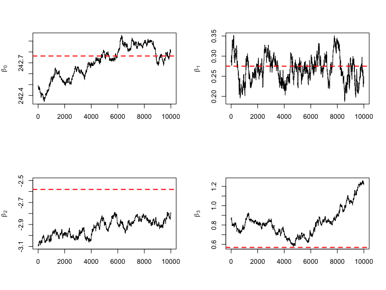

```r
# plot Markov chains - b0:b3
par(mfrow = c(2,2))

# plot chains for b0 - 'intercept'
plot(ts(out$batch[, 1]), type = "l", ylab = expression(beta[0]), xlab = "")
abline(h = lr_model$coefficients[1], col = "red", lty = 2, lwd = 2)

# plot chains for b1 - 'fixed acidity'
plot(ts(out$batch[, 2]), type = "l", ylab = expression(beta[1]), xlab = "")
abline(h = lr_model$coefficients[2], col = "red", lty = 2, lwd = 2)

# plot chains for b2 - 'volatile acidity'
plot(ts(out$batch[, 3]), type = "l", ylab = expression(beta[2]),
     ylim = c(-3.1, -2.5), xlab = "")
abline(h = lr_model$coefficients[3], col = "red", lty = 2, lwd = 2)

# plot chains for b3 - 'citric acid'
plot(ts(out$batch[, 4]), type = "l", ylab = expression(beta[3]), xlab = "")
abline(h = lr_model$coefficients[4], col = "red", lty = 2, lwd = 2)
```

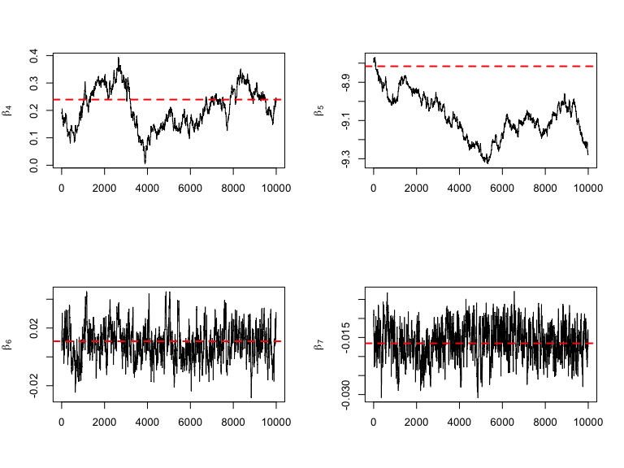

```r
# plot Markov chains - b4:b7
par(mfrow = c(2,2))

# plot chains for b4 - 'residual sugar'
plot(ts(out$batch[, 5]), type = "l", ylab = expression(beta[4]), xlab = "")
abline(h = lr_model$coefficients[5], col = "red", lty = 2, lwd = 2)

# plot chains for b5 - 'chlorides'
plot(ts(out$batch[, 6]), type = "l", ylab = expression(beta[5]), xlab = "")
abline(h = lr_model$coefficients[6], col = "red", lty = 2, lwd = 2)

# plot chains for b6 - 'free sulfur dioxide'
plot(ts(out$batch[, 7]), type = "l", ylab = expression(beta[6]), xlab = "")
abline(h = lr_model$coefficients[7], col = "red", lty = 2, lwd = 2)

# plot chains for b7 - 'total sulfur dioxide'
plot(ts(out$batch[, 8]), type = "l", ylab = expression(beta[7]), xlab = "")
abline(h = lr_model$coefficients[8], col = "red", lty = 2, lwd = 2)
```

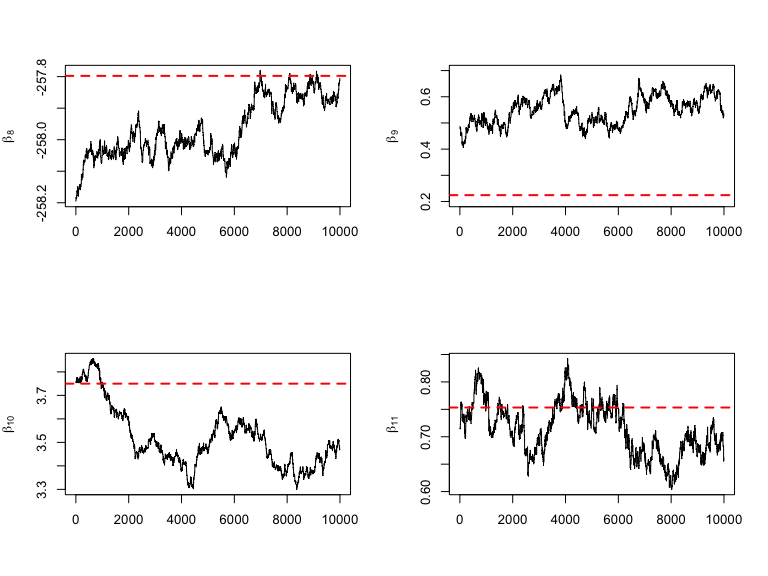

```r
# plot Markov chains - b8:b11
par(mfrow = c(2,2))

# plot chains for b8 - 'density'
plot(ts(out$batch[, 9]), type = "l", ylab = expression(beta[8]), xlab = "")
abline(h = lr_model$coefficients[9], col = "red", lty = 2, lwd = 2)

# plot chains for b9 - 'pH'
plot(ts(out$batch[, 10]), type = "l", ylab = expression(beta[9]),
     ylim = c(0.2, 0.7), xlab = "")
abline(h = lr_model$coefficients[10], col = "red", lty = 2, lwd = 2)

# plot chains for b10 - 'sulphates'
plot(ts(out$batch[, 11]), type = "l", ylab = expression(beta[10]), xlab = "")
abline(h = lr_model$coefficients[11], col = "red", lty = 2, lwd = 2)

# plot chains for b11 - 'alcohol'
plot(ts(out$batch[, 12]), type = "l", ylab = expression(beta[11]), xlab = "")
abline(h = lr_model$coefficients[12], col = "red", lty = 2, lwd = 2)
```

From the trace plots, we can see that our custom function performs better given our dataset and range of coefficients. This is due to having more freedom in adjusting tuning parameters and writing functions that can be problem-specific as appose to a general purpose function such as the *metrop()* function.

### References:

Cortez, P, Cerdeira, A, Almeida, F, Matos, F, Reis, J 2009, Modeling wine preferences by data mining from physicochemical properties, *Decision Support Systems*, vol. 47, pp. 547-553, viewed 2 August 2021, [URL](http://www.sciencedirect.com/science/article/abs/pii/S0167923609001377?casa_token=3l0RostJJXAAAAAA:QC5SBNWeoP2No8AVCA8EMu4R9yLCBh5gyZvsEMEVT1DxrzPwybfUyU0fWb8u4sqeqSyIUQBuIQI)

Nwanganga, F and Chapple, M 2020, *Practical Machine Learning in R*, Wiley, Hoboken, NJ, USA.

Hefin, R 2020, *Machine Learning with R, the tidyverse, and mlr*, Manning Publications, Shelter Island, NY, USA.

Roberts, GO and Rosenthal, JS 2001, Optimal Scaling for Various Metropolis-Hastings Algorithms, *Statistical Science*, vol. 16, pp. 351-367.

Brooks, SP and Gelman, A 1998, General Methods for Monitoring COnvergence of Iterative Simulations, *Journal of Computational and Graphical Statistics*, vol. 7, pp. 434-455.

Blitzstein, JK and Hwang, J, *Introduction to Probability*, CRC Press, Boca Raton, FL, USA.

Geyer, CJ and Johnson, LT 2020, *mcmc: Markov Chain Monte Carlo*, R package version 0.9-7, [URL](http://CRAN.R-project.org/package=mcmc)